# Inter‐platform ecosystems

Converted from PDF `CarballaSmichowski-InterPlatformEcosystems-2026-SMJ.pdf` · 38 pages · anchors: page `#pN`, block `#pN-bK`

Page 1

R E S E A R C H A R T I C L E

## Inter-platform ecosystems

Bruno Carballa-Smichowski <sup>1</sup> | Néstor Duch-Brown<sup>1</sup> |

#### Bertin Martens<sup>2</sup> | ´Alvaro Gomez-Losada<sup>3</sup>

1Joint Research Centre, European Commission, Edificio Expo, Seville, Spain

2Bruegel (Brussels) and Tilburg Law and Economics Centre, Tilburg University, Tilburg, Netherlands

3Department of Statistics and Operations Research, University of Seville, Seville, Spain

Correspondence Bruno Carballa-Smichowski, Joint Research Centre, European Commission, Edificio Expo, Seville, Spain. Email: bruno.carballa-smichowski@ec. europa.eu

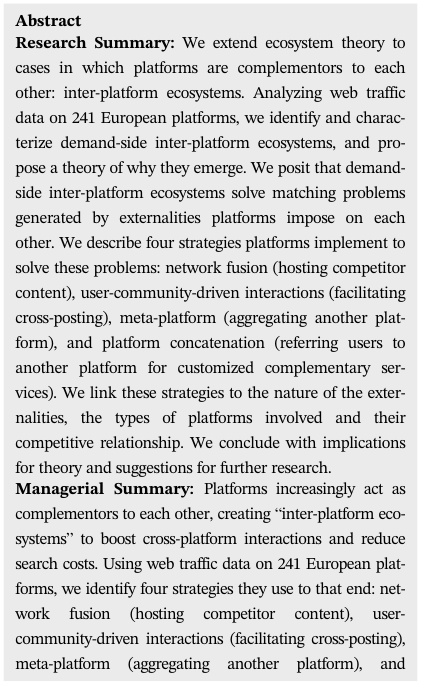

NOTE: figure/graphic rendered as an image from the PDF; its content is not machine-readable text. Caption (if any) follows as the next block.

**text found inside the figure**

Abstract Research Summary: We extend ecosystem theory to cases in which platforms are complementors to each

other: inter-platform ecosystems. Analyzing web traffic

data on 241 European platforms, we identify and characterize demand-side inter-platform ecosystems, and pro-

pose a theory of why they emerge. We posit that demandside inter-platform ecosystems solve matching problems

generated by externalities platforms impose on each

other. We describe four strategies platforms implement to solve these problems: network fusion (hosting competitor

content), user-community-driven interactions (facilitating cross-posting), meta-platform (aggregating another plat-

form), and platform concatenation (referring users to another platform for customized complementary ser-

vices). We link these strategies to the nature of the exter-

nalities, the types of platforms involved and their competitive relationship. We conclude with implications

for theory and suggestions for further research. Managerial Summary: Platforms increasingly act as

complementors to each other, creating “inter-platform ecosystems” to boost cross-platform interactions and reduce

search costs. Using web traffic data on 241 European platforms, we identify four strategies they use to that end: net-

work fusion (hosting competitor content), user-

community-driven interactions (facilitating cross-posting), meta-platform (aggregating another platform), and

Received: 21 July 2022 Revised: 4 November 2025 Accepted: 22 January 2026

DOI: 10.1002/smj.70070

This is an open access article under the terms of the Creative Commons Attribution License, which permits use, distribution and reproduction in any medium, provided the original work is properly cited. © 2026 The Author(s). Strategic Management Journal published by John Wiley & Sons Ltd.

1840 Strat Mgmt J. 2026;47:1840–1877. wileyonlinelibrary.com/journal/smj

Page 2

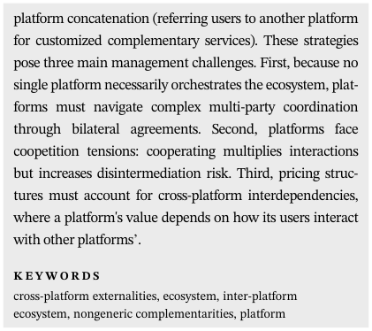

NOTE: figure/graphic rendered as an image from the PDF; its content is not machine-readable text. Caption (if any) follows as the next block.

**text found inside the figure**

platform concatenation (referring users to another platform for customized complementary services). These strategies

pose three main management challenges. First, because no single platform necessarily orchestrates the ecosystem, plat-

forms must navigate complex multi-party coordination

through bilateral agreements. Second, platforms face coopetition tensions: cooperating multiplies interactions

but increases disintermediation risk. Third, pricing structures must account for cross-platform interdependencies,

where a platform's value depends on how its users interact with other platforms’.

K E Y W O R D S

cross-platform externalities, ecosystem, inter-platform ecosystem, nongeneric complementarities, platform

#### 1 | INTRODUCTION

Over the last few years, there has been increasing interest in ecosystems. This is due to the fact that in many industries, the competitive advantage for firms is shifting “from superior standalone products and services to integrated value propositions based on an ecosystem of interdependent products from multiple, independent firms” (Adner, 2017). In particular, strategic management and antitrust scholars, as well as practitioners and regulators, are paying increasing attention to these dynamics in the context of “platform ecosystems,” as platform organizational forms and related business models are ubiquitous in the digital age (Gawer, 2022; G. Parker & Alstyne, 2008) and ecosystems tend to be based on platforms (Jacobides et al., 2020).

Following Jacobides et al. (2018), we define “ecosystems” as “a set of actors with varying degrees of multilateral, nongeneric complementarities that are not fully hierarchically controlled.” The extensive literature on platform ecosystems has so far focused on cases in which the ecosystem is constituted by a platform owner, (non-platform) complementors and end users (i.e., “intra-platform ecosystems”). However, as of yet, platfom ecosystem theory has overlooked cases in which a platform is a complementor to another platform. We call these “inter-platform ecosystems.”

For example, the popular platform TripAdvisor offers end users the possibility to find, compare, and book hotels, apartments, restaurants, and other services related to traveling. In order to do so, it relies on multiple complementors. Some of them (e.g., individuals providing ratings, independent hotels sharing real-time information on room prices and availability, etc.) are nonplatform complementors. Others are platform complementors, which in some cases orchestrate their own ecosystems. For example, platforms such as Booking.com or Hotels use modular technologies like application programing interfaces (APIs) to feed TripAdvisor with real-time customized discounts, prices, and availability information about accommodations from their own ecosystems. Similarly, when a user visits a restaurant on TripAdvisor, a button redirecting to the restaurant-booking platform The Fork is embedded. Google Maps, in turn, provides code to allow TripAdvisor and other platforms to embed a map of the location being consulted in their websites. In many countries, food delivery platforms such as Deliveroo or Rappi allow

CARBALLA-SMICHOWSKI ET AL. 1841

Page 3

TripAdvisor to communicate with their software so that end users can place an order from a restaurant without leaving TripAdvisor's website.

Inter-platform ecosystems are increasingly important organizational forms. “Super apps” like WeChat, Alipay, Grab, and Gojek—integrating multiple platforms into single interfaces— dominate Asian and African digital markets. Western platforms are following suit: Facebook incorporates Meta Pay, Marketplace, and Dating; Uber integrates food delivery, public transit, and reservations. Consumer demand supports continued Western expansion (Deloitte, 2023; Senterre et al., 2024), with 44%–55% of consumers interested in super apps (PYMNTS, 2022).

Generative AI should facilitate future inter-platform integration within an inter-platform ecosystem (Heimburg et al., 2024; Schmidt et al., 2024). ChatGPT exemplifies this through complementor integrations: Kayak GPT augments ChatGPT responses with live flight data, creating a conversational travel assistant for search, booking, and hotel/car rental recommendations. OpenTable, Expedia, and Instacart have developed analogous plugins. Moreover, this article shows empirically that multiple inter-platform ecosystems interweaving some of the most popular European platforms already exist.

Due to their increasing relevance, inter-platform ecosystems have become the subject of growing antitrust scrutiny. The merger between the online travel agency (OTA) platform Booking and eTraveli, which owns several flight and hotel booking platforms, is a landmark case. The European Commission blocked the merger, concluding that it would facilitate the embedding of content from some platforms into others and redirecting users between them, which would “likely increase barriers to entry/expansion for rival hotel OTAs and strengthen network effects” (European Commission, 2024, Section 6.7.2.3, p. 203). Similar concerns have been raised by other authorities in mergers involving inter-platform ecosystems spanning across multiple markets such as gambling (FDJ/Zeturf), job-seeking (Seek Asia Investments/JobStreet), wedding planning (Wedding Planner/Zank you), classified ads and car sales (Schibsted/Nettbil), e-commerce and real estate (Trade Me/Property NZ), and ticketing (viagogo/Stubhub).

These trends suggest that inter-platform ecosystems are more than a niche phenomenon, marking an important strategic development across various industries in the digital economy. However, existing platform ecosystem theory has yet to fully capture their distinctive characteristics and the strategies that drive them.

While inter-platform ecosystems share building blocks with intra-platform ones, key defining elements fall outside current theory's scope. In inter-platform ecosystems, platforms serve as complementors to each other, creating or strengthening cross-platform network effects while simultaneously generating value through their own intra-platform network effects and complementor ecosystems. This results in a constellation of interconnected value propositions connected within an inter-platform ecosystem. In contrast, current intra-platform ecosystem theory considers a single orchestrator, non-platform complementors, and one platform as the focal product with network effects bounded within that platform.

Relatedly, there is a gap in the literature regarding strategies motivating and enabling interplatform ecosystem creation. While recent research explains intra-platform ecosystem emergence through exogenous matching failures, innovation spillovers, and cooperation failures (Jacobides et al., 2024), and platform strategy theory addresses platform-centric and envelopment strategies (Schreieck et al., 2024), neither explains how platforms engage in inter-platform collaborations to establish inter-platform ecosystems.

We address these gaps by applying and extending the conceptual framework of the (platform) ecosystems literature. To guide this conceptualization, we develop an empirical methodology. This allows us to empirically identify signs of cross-platform failures, delineate demand-side inter-platform ecosystems (hereinafter DSIPEs), and detect the coordination and

1842 CARBALLA-SMICHOWSKI ET AL.

Page 4

cooperation patterns underlying them. The extension of current intra-platform ecosystem theory allows us to draw from a consolidated conceptual framework while ensuring its coherence with the theoretical insights we provide on inter-platform ecosystems. However, given the lack of theoretical and empirical literature on inter-platform ecosystems, we cannot rely on alreadystudied cases or examples to accomplish theory building.

To overcome this barrier, we carry out a quantitative identification of a subset of interplatform ecosystems: demand-side inter-platform ecosystems. The methodology builds on detecting nongeneric complementarities in consumption between platforms.<sup>1</sup> This allows us to constitute an empirical base of cases on which to build theory. Moreover, our approach has the advantage of generating a large and comprehensive sample of platforms. Hence, it makes our empirical base robust to build general findings.

We find that inter-platform ecosystems are built to minimize cross-platform negative information externalities or to solve cross-platform matching failures. The former arise from the search costs which the lack of inter-platform alignment can impose on their shared user base. For example, the higher the number of online retail platforms selling similar products and presenting product information differently, the more costly it is for multihoming users to search across them. If platforms coordinate and cooperate (e.g., through APIs and commercial agreements) with a price comparison platform, they can minimize these externalities, allowing users to access a one-stop shop platform that compares the offerings of multiple platforms. Cross-platform matching failures result from unhinged positive interaction externalities between users from different platforms. For example, the sellers and the buyers of two real estate platforms would benefit from interacting in order to have access to a wider network. In the absence of inter-platform alignment (e.g., by facilitating cross-posting), only multi-homing users would benefit from these additional interactions. Moreover, we posit that the strategies platforms implement to solve these failures depend on the nature of the externalities that trigger them, the types of platforms involved, and their competitive relationship. We identify four of such strategies: “network fusion,” “user-community-driven cross-platform interactions,” “meta-platform,” and “platform concatenation.” For each of them, we show the nature and the source of the cross-platform failure addressed by it; we identify the players and the actions taken by them to do so, and the pillars of joint value creation.

The remainder of the article is structured as follows. Section 2 presents the empirical methodology used and the resulting stylized facts.<sup>2</sup> Building on this empirical base and on intra-platform ecosystem theory, Section 3 provides theoretical insights into why and how demand-side inter-platform ecosystems emerge. In particular, it shows the types of crossplatform endogenous failures DSIPEs solve and the strategies their actors employ to do so. Section 4 offers implications for theory and sets out directions for further research.

2 | AN EMPIRICAL IDENTIFICATION OF DEMAND-SIDE INTER-PLATFORM ECOSYSTEMS

In this section, we present the methodology employed to empirically identify signs of crossplatform failures and delineate demand-side inter-platform ecosystems. We also provide the

1We therefore exclude from our analysis inter-platform ecosystems built on nongeneric complementarities in production. Although these may exist in our sample, we cannot observe them. Moreover, our results do not cover innovation platforms. 2Further technical details about the methodology are provided in Appendix A.

CARBALLA-SMICHOWSKI ET AL. 1843

Page 5

resulting main stylized facts for each of these points. Appendix A gives a more detailed account of the methodology.

#### 2.1 | Source and structure of the data

We use SimilarWeb<sup>3</sup> data capturing desktop traffic between domains by country of origin for European countries and the United States in 2020. Each observation represents traffic from an origin to a destination domain. We analyzed all the traffic involving 241 major European digital platforms across 20 EU Member States<sup>4</sup> where these platforms are most popular, yielding 4,254,212 observations. Table 1 describes the variables of the original dataset. For a thorough description of the other source types and why we have excluded them from the analysis see Appendix A “Exclusion of non-referral traffic.”

2.2 | Calculation of a proxy of demand-side nongeneric complementarities and choice of a threshold

In order to capture (i) nongeneric complementarities in consumption and (ii) the fact that ecosystem actors intentionally play different roles within inter-platform ecosystems, we only consider referral traffic, and not all the traffic between platforms that comes from other sources such as email or social media. SimilarWeb captures traffic that is classified into the following types of sources: “Direct,” “Mail,” “Referral,” “Social,” “Organic search,” “Paid search” and “Display ad.” Out of these categories, only referral traffic implies platform A tailoring its service to make it complementary with a specific platform or type of platform. Therefore, this traffic translates the fact that platforms “need to coordinate their investments through structures to enable” joint value creation (Jacobides et al., 2018). For example, when Google Search sends “organic search” or “paid search” traffic to platform B as a result of a query, this does not entail

TABLE 1 Description of the variables of the original database.

| Variable |  | Typeof |
| --- | --- | --- |
| name | Description | variable |
| domain | Thedomainthatreceivedtraffic Forexample wwwtripadvisorcom . , . . | String |
| in referral _ | Thedomainthatsentthetraffic Forexample wwwgooglecom . , . . | String |
| source type _ | Typeoftraffic dividedintothefollowingcategories:“Search/Organic” , , | Categorical |
|  | “Search/Paid”“Direct”“Referral”“Email”“Social”“DisplayAd”and , , , , , , | String |
|  | “Other” |  |
| visits | Numberofvisitsfromthedomainsendingthetraffictothedomainreceiving | Numeric |
|  | itfortheperiodofanalysis |  |
| ctry | Countryoforiginofthetraffic | String |

NOTE: table converted from PDF layout to HTML text; cell boundaries are reconstructed. See PDF if exact alignment matters.

Source: Own elaboration.

3See http://www.similarweb.com. 4Excluding Estonia, Cyprus, Latvia, Lithuania, Luxembourg, Malta, and Slovenia due to data unavailability.

1844 CARBALLA-SMICHOWSKI ET AL.

Page 6

a specific investment. Therefore, there is not a nongeneric complementarity with platform B: Google's PageRank algorithm is designed to find any type of website. On the contrary, Skyscanner made specific investments for its platform to send referral traffic specifically to airlines and flight ticket re-selling platforms. Therefore, we can say that there are nongeneric complementarities between Skyscanner and the websites to which it sends traffic.<sup>5</sup> Moreover, referral traffic allows us to observe cross-platform traffic resulting from platforms intentionally playing different complementary roles. For example, Skyscanner obtains part of the real-time data on flights it processes to offer its services from NDC Exhange, a platform that enables content interoperability between airlines, flight metasearch engines, distributors and other companies regardless of their API standards.<sup>6</sup> This shows a conscious effort by both Skyscanner and airlines to play complementary roles that enable joint value creation.

where RefTraf stands for “referral traffic,” A and B are two legally-independent platforms and n is the total number of platforms and non-platform domains.

#### 2.3 | Construction of a network and ecosystems detection

We only retain traffic for which the indicator captured in Equation 1 is of at least 10%. Using different methodologies (cf. Appendix A “Determination of a threshold value to differentiate occasional from significant cross-platform traffic”), we find this threshold value to eliminate occasional, non-significant cross-platform referral traffic. Then we generate a network<sup>8</sup> in which each platform constitutes a node, and the weight of the links is equal to the share of received referral traffic by the receiving platform. Finally, we apply a community detection algorithm to each network in order to obtain subgraphs of nodes representing a series of platforms or types of platforms related through demand-side linkages that can be considered to be part of the same ecosystem. See Appendix A “Community detection algorithm” for more details. The results are illustrated in Figure 1.

5See Appendix A “Exclusion of non-referral traffic” for more details on why we only consider referral traffic to translate nongeneric complementarities in consumption. 6See http://www.atpco.net/press/ndc-adds-skyscanner. 7Recall that ecosystems are an organizational form between “a set of actors with varying degrees of multilateral, nongeneric complementarities that are not fully hierarchically controlled” (Jacobides et al., 2018). Emphasis added. 8Other empirical contributions have used network analysis to detect the boundaries of ecosystems. However, in these contributions, scholars focus on supply-side ecosystems, and the content of the networks greatly differs from ours. See Appendix A “Use of network analysis to detect ecosystems in the literature” for more details.

CARBALLA-SMICHOWSKI ET AL. 1845

Page 7

3 | FROM CROSS-PLATFORM EXTERNALITIES TO INTER- PLATFORM ECOSYSTEM STRATEGIES

Intra-platform ecosystems emerge to solve exogenous “matching” or “systemic innovation” failures, on the one hand, and a coordination failure with and between its non-platform complementors, on the other hand (Jacobides et al., 2024). In contrast, inter-platform ecosystems solve endogenous cross-platform failures. When a platform's (ecosystem) generates externalities on another one, platforms can act as complementors to each other to internalize them.

We argue that inter-platform ecosystems are built to minimize cross-platform information externalities (increased search costs) or to solve cross-platform matching failures. The former arise between platforms with a shared user base, and result in less and lower-quality matches in each platform. The latter result from unhinged positive interaction externalities between users from different platforms. Moreover, we posit that the strategies implemented by platforms and/or users to solve these failures depend on the nature of the externalities that trigger them, the types of platforms involved and their competitive relationship.

Positive cross-platform interaction externalities exist when the value of a platform to (some of) its users increases with the interactions taking place in another platform. In the absence of

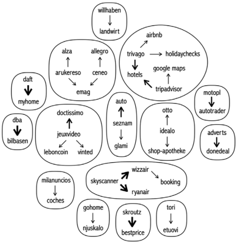

NOTE: figure/graphic rendered as an image from the PDF; its content is not machine-readable text. Caption (if any) follows as the next block.

FIGURE 1 Significant referral traffic between the major legally-independent platforms operating in Europe in 2020. Source: Own elaboration. The thickness of the links is proportional to the share of total received referral traffic. Traffic below 10% of total received referral traffic, between platforms belonging to the same conglomerate and including non-platform domains excluded. Twenty European countries included. Painted areas correspond to the communities detected.

1846 CARBALLA-SMICHOWSKI ET AL.

Page 8

inter-platform alignment, users from different platforms face disincentives to interact, which leads to cross-platform matching failures. For example, we find non-negligible yet statisticallyinsignificant referral traffic from the classifieds platform Markplaats to the secondhand car selling platform Autoscout24 in our sample. As shown by cached pages, this is explained by sellers of Autoscout24 secondhand cars posting links to their listings on Markplaats, which has a larger, generalist user base of buyers. Given that Markplaats forbids and hence censors these cross-postings,<sup>9</sup> the platforms do not align to facilitate these cross-platform interactions. Thus, these potential value-creating cross-platform interactions are hindered, leading to a crossplatform matching failure.

Negative information externalities arise between platforms sharing a user base when, in absence of inter-platform alignment, their co-existence imposes search costs to the shared user base. In this case, platforms do not internalize this negative externality. The case of the popular Hungarian classifieds (Jofogas) and product comparison online shopping comparison (Arukereso) platforms illustrates it. We find non-negligible yet statistically insignificant referral traffic from the former to the latter. Evidence from cached pages shows this results from some Jofogas sellers posting links to the product on Arukereso in order to provide Jofogas users with more detailed information and analysis about it. Given that Jofogas does not offer a built-in functionality to link a posting to its corresponding Arukereso page, information-savvy users of both platforms have to navigate them separately and face search costs.

When platforms face a cross-platform matching failure, both platform owners and users may solve it through a “network fusion” strategy. Alternatively, their users can lead a “usercommunity-driven cross-platform interactions” strategy, depending on the types of platforms involved and their competitive relations. When platforms impose negative information externalities on each other, they can align through a “meta-platform” or a “platform concatenation” strategy, depending on the types of platforms involved and their competitive relations.

Whether these strategies can be user-driven or not depends on the nature of the externality underlying them. In the case of strategies motivated by the internalization of negative information externalities (meta-platform and platform concatenation), and contrary to the strategies that solve matching failures (network fusion and user-driven cross-platform interactions), only platform owners, not users, can implement them. The reason is that the internalization of negative information externalities requires access to and the processing of vasts amounts of (protected) information. Hence, only through the cooperation between platforms (e.g, though a commercial partnership) and the deployment of technical means beyond those available to end users (e.g., APIs) can the meta-platform and platform-concatenation strategy be deployed. On the contrary, users located in different platforms wishing to interact can use the means provided by several platforms' architectures (e.g., cross-posting) to interact across platforms. Platform owners, in turn, may choose to facilitate (e.g., by providing a single user log-in or a crossposting functionality) these cross-platform interactions.

All the strategies behind DSIPEs lead to the generation of cross-platform non-generic complementarities, resulting in a joint value proposition around a cross-platform “focal user experience.” This contrasts with intra-platform ecosystems, in which the locus of joint value creation is the focal product: the platform. Moreover, also in contrast with traditional intra-platform

9Section IV-B-2.6 of Maarkplats' terms and conditions explicitly forbids cross-posting to other platforms in the case of vehicles. See https://www.marktplaats.nl/i/help/over-marktplaats/voorwaarden-en-privacybeleid/algemenegebruiksvoorwaarden.dot.html.

CARBALLA-SMICHOWSKI ET AL. 1847

Page 9

ecosystems, in the four strategies identified, the resulting joint value creations rest in part on the generation or strengthening of cross-platform (in)direct network effects.

As in intra-platform ecosystems, in inter-platform ecosystems, a platform uses boundary resources to facilitate value creation by enabling third parties to build on it, interconnect and offer complementary services Gawer (2021). In the DSIPEs detected, Application Programming Interfaces (APIs) stand out as a key boundary resource.<sup>10</sup> They act as formal control mechanisms defining how platform owners expose functionalities and data to external actors, enabling modularity and coordinated interactions (Ghazawneh & Henfridsson, 2013; Yoo et al., 2010). Boundary resources like APIs enable platforms not only to foster innovation but primarily to unlock and scale value jointly created across ecosystem participants by allowing seamless integration of distributed resources (Constantinides et al., 2018; Gawer, 2021).

Within the empirical demand-side inter-platform strategies studied in this section, APIs serve as crucial technological interfaces enabling real-time data integration, functionality sharing, and cross-platform user experiences. For example, when platform-owner-driven, the network fusion strategy relies on APIs like Trivago's Fast Connect to facilitate direct interaction between autonomous hotel booking platforms, while the meta-platform strategy leverages intermediaries such as NDC Exchange to overcome API standardization challenges in airline bookings. These APIs enable unlocking new value configurations jointly created by multiple independent platforms without merging governance structures.

In the remainder of this section, we present these four strategies. For each of them, we show what comprises the nature and the source of the problem it addresses; we identify the players and the actions they take to do so, and the pillars of joint value creation. This is summarized in Table 2 and discussed in detail. We illustrate each of these strategies with cases drawn from our empirical identification. Note that, as illustrated in Figure 1, inter-platform ecosystems can be built through the combination of more than one of these strategies, including cases in which a platform employs more than one.

#### 3.1 | The network fusion strategy

When two types of users have preferences for competing transaction platforms and incentives to interact, there can be positive interaction externalities between platforms. In this case, user interactions in a platform increase the value of a competing platform to another type of user. In other words, there are cross-platform indirect network effects.

Consider the case of a generalist marketplace and a marketplace specialized in electronics. The first one attracts generalist consumers, while the second one attracts electronics-savvy consumers. Consequently, the electronics marketplace attracts more sellers of electronics than the generalist one. However, sometimes generalist users want to purchase electronics. In absence of cross-platform alignment, non-multihoming generalist consumers will not transact with nonmultihoming electronics sellers in the competing platform. Thus, there is a cross-platform matching failure. More generally, as shown in the “Pattern 1” column of Table A4, this failure occurs between (partially-) competing transaction platforms. In our sample, we observe that, as

10Other boundary resources identified in the cases include user authentication mechanisms, content embedding and sharing features, technical interfaces beyond APIs (e.g., developer tools, channel managers, plugins), moderation policies and standards and protocols facilitating interoperability.

1848 CARBALLA-SMICHOWSKI ET AL.

Page 10

TABLE 2 Inter-platform ecosystems strategies.

|  |  | User-community- |  |  |
| --- | --- | --- | --- | --- |
|  |  | driven cross- |  |  |
|  |  | platform |  | Platform |
|  | Networkfusion | interactions | Meta-platform | concatenation |
| Natureof | Userinteractionsin | Usercommunity | Negativeinformation | Negative |
| the | aplatformincrease | interactionsina | externality(increased | information |
| externality | thevalueofa | platformincreasethe | searchcosts) | externality |
|  | competingplatform | valueofanother | platformsimposeon | (increasedsearch |
|  | toanothertypeof | platform to multi - | theirmultihoming | costs)platforms |
|  | user | homingusers | users | imposeontheir |
|  |  |  |  | multi -homing users |
| Sourcesof | Twotypesofusers | Complementary | The co-existence of | Platformsoffering |
| the | withpreferencesfor | resourcesand/or | competingplatforms | complementary |
| externality | competing | usercommunities | withmultihoming | productsinan |
|  | transaction | aresplitacross | usersanddistinct | uncoordinatedway |
|  | platformshave | multipleplatforms | designs information , | toashareduser |
|  | incentivestointeract |  | categorizations price , | base |
|  |  |  | structures services , |  |
|  |  |  | andcomplementors |  |
| Endogenous | In absence of cross- | In absence of cross- | In absence of cross- | In absence of cross- |
| matching | platform | platform | platform | platform |
| problems | coordination the , | coordination auser , | coordination , | coordination , |
| addressed | twousertypesfrom | communitycannot | competingplatforms | platformsoffering |
|  | competingplatforms | interactwithcontent | failtorecognizetheir | complementary |
|  | lackincentivesto | producedinanother | interdependencies | servicesfailto |
|  | interact | platform | andtocooperatefor | recognizetheir |
|  |  |  | jointvaluecreation | interdependencies |
|  |  |  |  | andtocooperatefor |
|  |  |  |  | jointvaluecreation |
| Actorsand | Competing | Aplatformwitha | Competing | Platformsoffering |
| competitive | transaction | usercommunity | transactionplatforms | complementary |
| relations | platforms | (originplatform)and |  | productslocatedin |
|  |  | anotherdestination |  | adjacentor |
|  |  | platform |  | unrelatedmarkets |
|  | Multi -homing users | Atleastoneuser | Ametasearch | Multi -homing end |
|  |  | communitywith | platforminan | users |
|  |  | multi -homers | adjacent or partially- |  |
|  |  |  | overlappingmarket |  |
|  |  |  | Multi -homing users |  |
| Actors' | If platform-owner- | Aplatform'suser | Themetasearch | Afteratransaction |
| actionsto | driven: | community | platformhoststhe | takesplaceina |
| enablejoint | Aplatformhoststhe | generatescontent | contentof | platform the , |
| value | contentofa | thatenhancesthe | transactionplatforms | platformoffersa |
| creation | competingplatform | userexperienceof | andprovides | complementary |
|  |  | anotherplatform | comparablemetrics | productfrom |
|  |  | Theplatformwitha | acrossplatformsand | anotherplatform |
|  |  | usercommunity | otheranalysistools | customizedtothe |
|  |  | accommodates cross- |  |  |

NOTE: table converted from PDF layout to HTML text; cell boundaries are reconstructed. See PDF if exact alignment matters.

CARBALLA-SMICHOWSKI ET AL. 1849

Page 11

a result of this failure, the demand-side linkages between platforms outside a DSIPE are 29 percentage points lower in intensity than those inside a DSIPE.

In order to solve this failure, competing platforms can align through the network fusion strategy. A platform can host content from a competing one, thereby inducing some of its previously non-multihoming users to multi-home and interact there. Thus, their networks become partially fusioned. Examples of this strategy in our sample include, among others, users accessing Coches (a cars classifieds platform) through Milanuncios (a generalist classifieds platform), or Willhaben (a generalist retail marketplace) inducing user cross-traffic to Landwirt (a machinery marketplace).

When platforms employ a network fusion strategy, the platform sending traffic to another one turns the recipient platform into its complementor. In so doing, the platforms fuse their networks, thereby generating a joint value proposition that is not anchored in a platform as the

TABLE 2 (Continued)

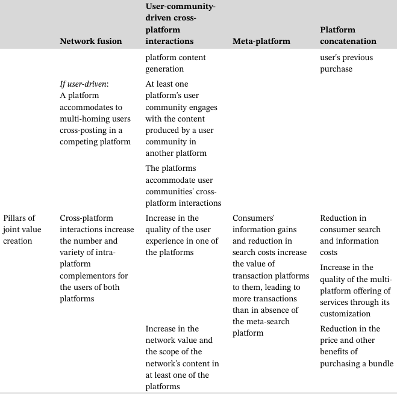

NOTE: complex table shown as an image of the PDF; the text below is a rough machine extraction and may be mis-aligned.

**extracted text (unreliable layout)**

Source: Own elaboration.

1850 CARBALLA-SMICHOWSKI ET AL.

Page 12

focal product. Instead, the focal user experience (e.g., online retail, tourism, etc.) is co-created across platforms through their alignment. The resulting increase in cross-platform interactions strengthens the cross-platform network effects between the platforms, leading to more value creation.

CARBALLA-SMICHOWSKI ET AL. 1851

Page 13

Some strategic considerations can lead platforms to turn a blind eye in search of increasing cross-platform value creation. For example, given the structure of fees or the ease of use for buyers and landlords, one platform may be more attractive to buyers and the other one to sellers. In this case, the platform that is more attractive to buyers could tolerate to a certain extent that sellers post links to the competing platform. Although this would imply losing the transaction to a competitor, it would make the platform even more attractive to buyers, thus increasing the value for them and the probability of a future transaction within the platform.

#### 3.2 | User-community-driven cross-platform interactions

When complementary resources and/or user communities are split across multiple platforms, there can be positive interaction externalities between them. This happens when the value of a platform to multi-homing users increases with the interactions that take place within a user community in another platform. As in the case of the network fusion strategy, there are crossplatform network effects.

As shown in the “Pattern 2” column of Table A4, this failure occurs between a platform hosting an active user community and any other type of platform. In our sample, we observe that, as a result of this failure, the demand-side linkages between platforms outside a DSIPE are 15 percentage points lower in intensity than those inside a DSIPE. The inter-platform ecosystem around the gaming news and forum JeuxVidéo offers an illustration of this strategy. As shown by our analysis of cached pages of JeuxVidéo with links to Le Bon Coin and Vinted, many JeuxVidéo users are also active in Le Bon Coin (a generalist classifieds platform) and Vinted (a secondhand fashion marketplace). They use JeuxVidéo's forum to seek advice from its community regarding the use of these platforms (user experience, payment options, how to haggle with sellers, warnings against scams, etc.) and some of the products offered there. This is because these platforms do not offer a forum functionality where users can obtain this type of information. More importantly, the community they know, regularly engage with and likely trust better on this information, is located in another platform, JeuxVidéo. Similarly, JeuxVidéo users that are also present in the platform Doctissimo (a health news and forum platform) would like to discuss content produced by the Doctissimo forum community with nonmulti-homing users from JeuxVidéo. In absence of cross-platform coordination allowing JeuxVidéo users to share content from other platforms within their community, they face disincentives to interact with it, leading to a cross-platform matching failure. Similar types of interactions were found by analyzing the cached pages of JeuxVidéo linking to other platforms for which demand-side linkages of an intensity between 1% and 10% were found. However, as translated by the value of this indicator, these interactions are not sufficiently frequent to signal the existence of nongeneric complementarities in consumption between the platforms. For example, we found 8940 user posts in JeuxVidéo with links to the marketplace Cdiscount and 11,500 (i.e., 29% more) with links to Le Bon Coin.<sup>14</sup> Moreover, Cdiscount received 36% more referral traffic in 2020 than Le Bon Coin.

Multi-homing users take an active role in solving this failure. They identify content from a platform and kickstart interactions within the user community of another one that enhance the value of the first platform. In doing so, they take an active role in creating nongeneric complementarities between the platforms, which leads to joint value creation across platforms. For

14Last accessed on April 29, 2024.

1852 CARBALLA-SMICHOWSKI ET AL.

Page 14

example, as shown by cached pages in which multi-homing users seek advice about other platforms' functioning or offerings (as in the case of Le Bon Coin and Vinted), they increase those platforms' value to them by providing information that facilitates and stimulates their use. In this case, the user community of a platform acts as a complementor to other platforms. Conversely, the value of the platform with the user community increases, as the functioning or offerings of another platform generate content that is valuable to multi-homing users. In the case in which the content of a platform is discussed within another platform's user community, the former acts as a complementor of the latter. The network value of the platform discussing another platform's content increases, as the latter provides new content and increases the possibility of interactions within the discussing platform's community. In both cases, the joint value creation is underpinned by the strengthening of cross-platform direct network effects. As a result, there is an increase in the volume and the quality of interactions within the platforms.

As in the case of the user-driven network fusion strategy, platform owners take a passive role in this joint value creation strategy. They nonetheless contribute to it by generating the content (specialized gaming or health news) and providing the resources (forum, marketplace) needed for the multi-homing users to be able to generate value from cross-platform interactions. Moreover, the owner of the platform in which another platform's content is discussed (JeuxVidéo in our sample) allows multi-homing users' posting of other platforms' links by not blocking them and by choosing not to use its moderation rights to eliminate this content (e.g., by modifying its “moderation charter”). In doing so, it accommodates cross-platform interactions and the joint value creation they bring about. In all of the cases evoked, the focal point of value creation is not a single platform but a focal user experience. In the JeuxVidéo/Le Bon Coin and JeuxVidéo/Vinted cases, the focal user experience of online retail is split between two types platforms: the online retail platform and a specialized forum in which users provide ancillary information services tailored around the specificity of the functioning of the retail platform. In the case of JeuxVidéo/Doctissimo, the user experience of user community interactions around common topics is split between two platforms with complementary user communities.

#### 3.3 | The meta-platform strategy

The co-existence of multiple competing platforms (ecosystems) offering distinct designs, information categorizations, price structures, services, and complementors increases the necessary cognitive effort multihoming users have to engage in to compare their offerings. This, coupled with the fragmentation of such information across platforms, translates into a negative information externality competing platforms impose on each other. The more fragmented and dissimilar the information is across competing platforms, the higher the search costs users face when comparing offerings on multiple platforms. This leads to less and lower-quality matches.

Consider the case of a user wanting to buy a smart TV online. She will try to find the brand and model that fits her needs and budget. In order to do so, she will compare offerings from generalist and specialized online marketplaces. Given that platforms differ in the type of information provided about each TV, their design, the prices at which the same brand and model is offered and other complementary services (e.g., warranty period, insurance costs, delivery conditions, etc.), the user faces search costs when comparing them. This might lead her not to (correctly) compare all the options and, as a result, to abandon the purchase or to settle for an a product that is not the best available match. More generally, as shown in the “Pattern 3” column of Table A4, this decrease in matching volume and quality occurs when end users fail to

CARBALLA-SMICHOWSKI ET AL. 1853

Page 15

(sufficiently) compare competing transaction platforms. In our sample, we observe that, as a result of these negative information externalities, the demand-side linkages between metasearch platforms allowing this comparison with transaction platforms outside a DSIPE are 25 percentage points lower in intensity than those inside a DSIPE. The meta-platform strategy proposes a solution to the matching problems this crossplatform information externality creates. By coordinating and cooperating with multiple competing platforms that share relevant data with it (e.g., prices, product characteristics, stocks, etc.), a meta-search platform hosts the offerings of multiple platforms in a one-stop shop along with comparable metrics and analysis tools (e.g., ranking of offerings by a certain feature, comparison of a set of products, rating of competing transaction platforms, etc.), reducing so the negative externalities competing platforms impose on each other. In the cases depicted in Figure 1, this is the case for many types of marketplaces, lodging and travel services platforms. For example, the flights metasearch platform SkyScanner provides flight information from multiple platforms. It allows users to compare their offerings in terms of multiple variables such as price, flight duration, number of layovers, and so forth.

As in the case of the platform-driven network fusion strategy, platforms create nongeneric complementarities building on a technical interface that allows the metasearch platform to interact with other platforms' systems. For example, the price comparison platform Idealo relies on an ecosystem of certified technology partners offering plugins, apps, and core integration for merchants and marketplaces to connect their networks to Idealo. Another example is Skyscanner, which obtains part of the real-time data on flights it processes to offer its services from NDC Exhange, a platform that enables content interoperability between airlines, flight metasearch engines, distributors and other companies regardless of their API standards.<sup>15</sup> We observed these mechanisms in the 28 cases identified within and outside a DSIPE. However, as mentioned above, within-DSIPE transaction platforms received a substantially higher share of their referral traffic from a metasearch platform than their outside-DSIPE counterparts.

The reduction in search costs generated by platform alignment through a meta-search platform increases the value of the transaction platforms to their consumers. This results in joint value creation between the transaction platforms and the metasearch platform. The transaction platforms become complementors of the meta-search platform. However, the focus of the value creation is not the latter but the user experience. The user experience (e.g., online retail, tourism) is separated into two types of platforms: a metasearch platform that provides information and analysis, and a transaction platform in which transactions are carried out. The joint value creation this strategy brings about results in an increase in the number of transactions through different channels. The functionalities that a meta-search platform comparing multiple competing platforms can offer stimulate user consumption. For example, the price comparison platform Idealo shows users a cross-platform historical price chart and price alerts for a given product. Skyscanner, in turn, provides advice on whether to buy or to wait on a flight ticket purchase based on historical price data. This type of information stimulates purchases, leading to more transactions. Moreover, meta-search platforms typically offer mix-and-match solutions that combine offerings from multiple platforms. Finally, the existence of high-quality metasearch platforms encourages consumers to finalize their purchase rather than abandoning it after visiting one or more competing platforms and failing to find a good match to their needs. Therefore, platform alignment generates cross-platform indirect network effects. The more end

15See http://www.atpco.net/press/ndc-adds-skyscanner.

1854 CARBALLA-SMICHOWSKI ET AL.

Page 16

users there are in the meta-search platform, the more valuable this platform becomes to sellers and their respective transaction platforms, and vice versa.

#### 3.4 | The platform concatenation strategy

When platforms with a shared user base offer complementary products in an uncoordinated way, they impose a negative information externality on multi-homing users. Given the lack of inter-platform alignment, multi-homing users purchasing complementary products from different platforms face search costs.<sup>16</sup>

For example, a user planning a trip has to buy complementary services such as transportation and lodging. The user has to combine two services, typically offered by different platforms (a flight metasearch and/or an airline platform, on the one hand, and a lodging metasearch and/or a lodging platform, on the other hand) so as to fit a schedule and a budget. Similarly, in order to locate the airport, the hotel, a restaurant and tourist attractions booked or found in different platforms, a user can resort to an online maps platform to plan her itinerary. In absence of inter-platform alignment, after interacting with the flight metasearch platform, the user faces search costs to find an accommodation in a lodging platform that fits the flight she booked in the metasearch platform. As shown in the “Pattern 4” column of Table A4, this happens between various types of platforms that do not fit the patterns described in patterns 1, 2 and 3. Examples include but are not limited to marketplaces leading end users to delivery platforms and platforms offering special deals and discounts from participating retailers or tourism platforms leading to online mapping platforms. In our sample, we observe that, as a result of this failure, the demand-side linkages between platforms offering complementary products outside a DSIPE are 22 percentage points lower in intensity than those inside a DSIPE.

16Note that the nature of the externality platforms create on each other (increasing search costs) is the same as in the meta-platform strategy. However, as developed below, the types of platforms involved (complementary, non-competing platforms, rather than competing platforms selling substitutes) differ; as a result, platforms engage in a different strategy to minimize the resulting matching problems.

CARBALLA-SMICHOWSKI ET AL. 1855

Page 17

This inter-platform alignment underlying the platform concatenation strategy results in a joint value creation in several ways. First, it reduces users' search costs. Second, it increases the quality of the multi-platform offering by customizing each individual platform to the user experience. Third, in some cases, users obtain price reductions and other benefits from purchasing a bundle from platforms belonging to the same inter-platform ecosystem. For example, when a user buys from one of Wizzair's partner sites, it obtains 5% Wizzair credit. This benefit to consumers, as well the ease of access to a customized complementary service, internalize the crossplatform externalities. Fourth, it generates cross-platform indirect network effects. The more and higher-quality sellers of complementary services there are in the second platform (e.g., a car rental platform), the more valuable the first platform (e.g, the lodging platform) becomes to end users, and vice versa.

The locus of the joint value proposition is not a platform but a cross-platform (touristic, in the examples above) user experience.

#### 4 | FURTHER RESEARCH DIRECTIONS

We have studied how platforms solve different types of cross-platform failures by aligning within demand-side inter-platform ecosystems. The strategies they employ to do so depend on the nature of the externalities that trigger these failures, the types of platforms involved and their competitive relationship. In this respect, our findings present similarities, but also many differences with intra-platform ecosystem theory. We summarize the comparison between the two in Table 3.

The differences between the features of intra- and (demand-side) inter-platform ecosystems open up a promising research agenda that extends platform ecosystem theory to (demand-side) inter-platform ecosystems in multiple directions. In the remainder of this section, we focus on some prominent questions for further research our findings prompt but cannot answer.

#### 4.1 | Inter-platform ecosystems' governance

We have seen that demand-side inter-platform ecosystems can emerge as the result of bilateral strategies on the part of multiple platforms to internalize the externalities they impose on each other. These strategies can either be driven by platform owners or users (communities).

17See https://www.agora.pl/ogloszenia-motoryzacyjne-z-autotrader-pl-dostepne-w-multiwyszukiwarce-moto-money-pl.

1856 CARBALLA-SMICHOWSKI ET AL.

Page 18

Moreover, with the exception of DSIPEs that build exclusively on the meta-platform strategy, platforms pre-exist the inter-platform ecosystems to which they belong. This contrasts with intra-platform ecosystems, in which (i) the platform owner is the only actor that decides on

TABLE 3 Comparison of intra-platform and demand-side inter-platform ecosystems main features.

|  |  | Demand -side inter-platform |
| --- | --- | --- |
| Category | Intra-platform ecosystems | ecosystems |
| Reasonforthe | Existenceof(i)exogenouscooperation | Existence endogenous of either cross- |
| ecosystemto | externalities between a platform and (ii) non- | platformcooperationexternalitiesorof |
| emerge | platformfirmsandconsumptionexternalities | cross-platform matching externalities |
|  | betweentwotypesofusers |  |
| Conditionsfor | Cooperationthroughnongeneric | Cooperationthroughnongeneric |
| theecosystem | complementaritiesthatcreateajointvalue | complementaritiesinconsumptionthat |
| toemerge | propositionbycomplementingafocal | createajointvaluepropositionbasedon |
|  | platform | cross-platform interactions or |
|  |  | transactions |
|  | Modularitybetweentheplatform's | Modularitybetweenplatforms'core |
|  | componentsopentocomplementorsandits | functionalitiesthroughstandardized |
|  | complementorsthroughboundaryresources | interphases (e .g APIs) to spur cross- ., |
|  | suchastoolkits(eg SDKs)orstandardized . ., | platform interactions or cross-platform |
|  | interphases (e .g APIs) to co-create ., | consumption |
|  | complementaryservicesbuiltonafocal |  |
|  | product |  |
|  | Firmsareindependent | Firmsareindependent |
| Locusofjoint | Theonlyplatformasthefocalproduct | A cross-platform focal user experience |
| valuecreation |  |  |
| Structure | Centeredonavertical | Centered on a vertical or a cross-industry |
|  |  | community |
|  | Hub -and -spoke around the focal platform | Various forms including a (nested) hub - |
|  |  | and -spoke |
| Members | Platformowner | Platformowners/complementors |
|  | Complementors |  |
|  | Endusers | Endusers |
| Membership | Theplatformownercontrolsaccessto | Membershipdecisionsaredistributed . |
| rights | membershipandcomplementors | Theyrelyoneitherbilateralcollaborations |
|  | autonomouslydecidetojoinanecosystem | betweenplatformownersoruser |
|  |  | initiativestoleratedbyplatformowners |
|  |  | Platforms and their intra-platform |
|  |  | ecosystemcomplementorscanbecome |
|  |  | part of an inter-platform ecosystem |
|  |  | withoutautonomouslydecidingit |
|  | Complementors do not pre-exist the | Platform-complementors pre-exist the |
|  | ecosystem | ecosystem |
| Typesof | Intra-platform network effects | Intra-platform and cross-platform |
| networkeffects |  | networkeffects |

NOTE: table converted from PDF layout to HTML text; cell boundaries are reconstructed. See PDF if exact alignment matters.

Source: Own elaboration.

CARBALLA-SMICHOWSKI ET AL. 1857

Page 19

membership rules; and (ii) complementors and end users autonomously decide whether to join an ecosystem (Kapoor, 2018). This set of divergences opens up interesting and unexplored questions about (demand-side) inter-platform ecosystems.

#### 4.1.1 | Pricing structure

It follows from the above that, within DSIPEs, the value of network membership to a platform's user (be it an end user or a complementor) depends on the decisions of users on other platforms. Thus, platform owners not only have to decide on a pricing structure that takes the interdependencies between the platforms' sides into account (as shown in the early platform literature Caillaud & Jullien, 2001; Hagiu, 2006; Rochet & Tirole, 2003; G. G. Parker & Van Alstyne, 2005), they also have to take into account cross-platform interdependencies. How does this affect the pricing structure of a platform that is part of an inter-platform ecosystem, as opposed to one that is not? Does the pricing strategy depend on the strategy underlying the cross-platform interdependencies?

In intra-platform ecosystems, “governance is is centralized by necessity” (Jacobides et al., 2024). In demand-side inter-platform ecosystems, there are at least three reasons to believe that, in

1858 CARBALLA-SMICHOWSKI ET AL.

Page 20

most cases, platform governance is not centralized. First, when users (communities) drive the creation of non-generic complementarities in consumption between platforms, they (partially) take on a task that is traditionally the prerogative of the orchestrator: keeping co-specialized assets in value-creating alignment and in dis(investing) new (old) ones (Teece, 2010). Second, if platforms are complementors to each other (as in the network fusion strategy, for example), it is not clear why one of the platforms would be the “natural,” sole orchestrator of the interplatform ecosystem. Third, digital interfaces, which constitute one of the boundary decisions of a platform (Gawer, 2021), are set up at the platform (not the DISPE) level. A focus on the role played by APIs in DSIPEs illuminates this last point.

In intra-platform ecosystems, APIs “define the degree of openness and the balance of directionality of the 2-way exchange of data between the platform and each of its sides” (Gawer, 2021). In DSIPEs, APIs also regulate inter-platform interactions. When platform A grants API access to B, and B connects to C, A loses direct control, creating decentralized API governance. This logic extends to other boundary resources (plugins, moderation policies), reducing any platform's control over critical ecosystem assets and transaction characteristics. Decentralized API control thus intensifies the inherent tension between enabling third-party value creation and maintaining control (Ghazawneh & Henfridsson, 2013; Yoo et al., 2012).

Moreover, DSIPEs' governance is more complex than in intra-platform ecosystems due to the existence of two layers of governance and transitive network effects. In as much as the participating platforms orchestrate their own intra-platform ecosystems (as it is the case of the vast majority of the platforms in our final sample), governance is two-layered. In the first layer, a platform owner orchestrates its intra-platform ecosystem. In the second layer, platforms have to decide how to govern the demand-side linkages that interrelate them at the DSIPE level. In addition, given that, as seen in Figure 1, inter-platform ecosystems can indirectly connect two platforms through a common third one, they exhibit “transitive network effects.” The latter occur when “when the relationship between two actor groups indirectly influences a third group, even though no direct link exists between the first and third parties” (Schmidt et al., 2024).

The complex nature of inter-platform ecosystems' governance opens up research questions to which case studies could contribute in answering. Does the decentralized governance of demand-side inter-platform ecosystems lead to the same functional ecosystem failures observed in other decentralized ecosystems (Hsieh & Vergne, 2023; Pidun et al., 2021)? Contrary to many decentralized ecosystems studied in the digital realm (e.g., ecosystems based on blockchain), DSIPEs do not suffer from the rigidity of a decentralized decision-making binding protocol. Nor do they seem to be in a technologically fast-paced environment requiring rapid decisionmaking.

Under which conditions do actors in inter-platform ecosystems set up governance instances, as in open-source communities (O'Mahony & Ferraro, 2007)? Recent studies of supply-side inter-platform ecosystems indicate that the platform supplying the “ecosystem good” plays the role of the orchestrator at the inter-platform level. In China, Alipay orchestrates an interplatform ecosystem based on its mobile payment service, which is embedded in multiple platforms (Zhang & Williamson, 2021). Similarly, ChatGPT uses plugins to integrate information generated by travel booking, journey planning and specialized travel platforms (Schmidt et al., 2024). However, in demand-side inter-platform ecosystems, as our sample shows, there is not an ecosystem good. Could the platform with the gateway to users, if any (e.g., the aggregator or the platform where the user journey of complementary platform services begins), be the “natural orchestrator” of a demand-side inter-platform ecosystem? Visnjic et al.'s (2016) study of

CARBALLA-SMICHOWSKI ET AL. 1859

Page 21

cities, which they conceptualize as “ecosystems of ecosystems” akin to the DSIPEs studied in this article, shows city authorities play the role of orchestrating multiple, interrelated ecosystems. In absence of a natural orchestrator, the potential complexity of coordination within inter-platform ecosystems should favor choosing common ownership. There is only a small amount of literature looking at supply-side inter-platform ecosystems under common ownership (“multiproduct”/“experience” ecosystems or “platform constellations” in Jacobides' (2022) and Staykova and Damsgaard's (2015) terms, respectively). Case studies of demand-side inter-platform ecosystems in the light of this literature could be illuminating to understand the strategic considerations leading to common or independent ownership within demand-side inter-platform ecosystems.

#### 4.1.4 | Membership

It follows from the above that in demand-side inter-platform ecosystems membership is more fluid than in intra-platform ecosystems. In the former, after an end user or an intra-platform complementor joins a platform ecosystem, it can later also become (perhaps unwillingly) part of a DSIPE if the platform owner or end users (communities) implement one of the strategies studied in this article. How do platform owners decide the extent and the permeability of the inter-platform ecosystem memberships they create or accommodate? Although, as shown in this article, demand-side inter-platform ecosystems are solutions to endogenous cross-platform failures that benefit end users, they might also disadvantage intra-platform complementors if membership is too open. For example, by working with flight metasearch platforms, airlines' platforms face increased competition from other airlines. This can hurt their profits and their DSIPE complementors', such as associated lodging or car rental platforms. This takes us to the next avenue for further research: coopetition.

#### 4.2 | Coopetition within inter-platform ecosystems

The literature has widely analyzed how, in intra-platform ecosystems, complementors can compete both with the platform owner and other complementors for value capture. This results in coopetition dynamics, as firms belonging to the same ecosystem need to simultaneously cooperate through the creation of nongeneric complementarities in order to create value and compete for value capture (Ansari et al., 2016; Gawer & Henderson, 2007; Hannah & Eisenhardt, 2018; Panico & Cennamo, 2022; Zhu & Liu, 2018).

Revisiting these findings in light of demand-side inter-platform ecosystems opens an interesting avenue for research, notably when the “network fusion” or the “meta-platform” strategy underpins platforms' interactions. Our findings suggest that, as a result of these strategies, not only inter-platform cooperation increases but also competition. In the case of the meta-platform strategy, competition between the platforms that complement the aggregating platform should increase, as the latter makes each platform's user base less captive. At the same time, interplatform cooperation results in a larger potential user base for each complementor. Platforms, in turn, prefer attracting users directly to avoid paying referral fees to the aggregating platform, as is the case of third-party vendors in transaction platforms (Hagiu & Wright, 2023). In the case of the network fusion strategy, competition between the complementors of each platform should intensify in conjunction with the expansion of the network size the fusion entails.

1860 CARBALLA-SMICHOWSKI ET AL.

Page 22

However, given the distributed and complex nature of governance in inter-platform ecosystems, there is no single orchestrator that can set up mechanisms to navigate coopetition at the inter-platform ecosystem level, as platform owners are only capable of acting on their own architectural control. Moreover, the owners of the platforms making up the inter-platform ecosystem are likely to have different incentives on the balance between competition and cooperation at the inter-platform ecosystem level. What mechanisms can platforms set up to navigate the coopetitive dynamics at this level? Do they cooperate to find this balance? How does this affect platforms' architectural choices and their own intra-platform ecosystem coopetition dynamics?

This raises a larger question on the competitive strategies platforms might pursue within an inter-platform ecosystem. Two polar strategies can be envisioned. Platforms may try to develop into the gateway to other complementary platforms in order to become users' primary access point to the ecosystem, as in Heidhues et al. (2024). Alternatively, platforms could try to become ubiquitous, high-value complementors to all other platforms with a shared user base. We could expect the first strategy to be preferred by platforms that followed a meta-search platform or a platform concatenation strategy. In these strategies, the user journey begins at a single platform: the aggregator or the platform that triggers the purchase of subsequent complementary services, respectively. This should give more control and bargaining power to that platform and may lead to envelopment attempts by which the other platforms try to become the platform with privileged access to the inter-platform ecosystem's user base. In contrast, we could expect the DSIPEs that follow a user-community-driven cross-platform interactions strategy to be made of platforms opting for the second strategy, as there is no clear beginning of the user journey and the platforms are not active in overlapping markets.

A related avenue for research is the exploration of envelopment strategies in inter-platform ecosystems. Network fusion and platform envelopment strategies share some key characteristics. They both leverage overlapping user bases and common components. For instance, the marketplaces and price comparison platforms identified in this strategy share components such as product catalog and transaction management systems, seller management tools, review and rating mechanisms, and product data aggregation technologies (e.g., direct feeds, APIs, web scraping). Both strategies also seek to provide users with more functionalities than singleplatform experiences. As in envelopment attacks of weak substitutes, the platforms in the network fusion strategy “serve the same broad purpose but satisfy different sets of users needs” (Eisenmann et al., 2011), enabling them to exploit economies of scope in marketing to multihoming users.

However, the two strategies differ in how they achieve these objectives and in the nature of the inter-platform relations they entail. In the network fusion strategy, platforms cooperate by facilitating cross-platform interactions between multi-homing users. Envelopment, by contrast, involves a unilateral decision by a platform (the attacker) to bundle its functionalities with some of the target platforms'. In doing so, it seeks to gain a competitive advantage over the target platform and reduce users' incentives to multihome (Eisenmann et al., 2011).

Given the similarities between the two strategies, the network fusion could serve as a foundation upon which envelopment strategies build. For example, the “Craigslist hack” (Kretschmer et al., 2022)<sup>18</sup> can be re-interpreted as a network fusion strategy that resulted in envelopment. However, DSIPEs could also be a cooperative alternative to bundling. Under

18In its initial phase, Airbnb allowed its users to automatically re-post their listings on Craigslist, which by then had a much larger user base.

CARBALLA-SMICHOWSKI ET AL. 1861

Page 23

which conditions do platforms choose to envelop, rather than to maintain the inter-platform ecosystem? What kind of safeguards can platforms establish to avoid envelopment within an inter-platform ecosystem? There is an interesting avenue for contributions that revisit platform envelopment and related strategies' case studies in light of inter-platform ecosystems. Such work could provide insights into how and to what extent the latter can be a pathway or an alternative to platform envelopment.

#### 4.3 | Inter-platform ecosystems' performance

We have shown that demand-side inter-platform ecosystems solve either cross-platform information externalities or cross-platform matching failures. In doing so, they spur interactions that would not have taken place otherwise, which should increase value creation. However, we do not know what the impact is of DSIPEs on each platform's value capture and its performance. Let us first consider market shares as a measure of performance. Consider the case of two online retail platforms, H and S, following the network fusion strategy. Platform H hosts listings from platform S. Cross-platform network effects make platform S more valuable to sellers, as they can access buyers from both platforms. Conversely, they make platform H more valuable to consumers, as they can access both platforms' sellers. It is a priori ambiguous which platform's seller and consumer user base will increase or decrease as a result. The extent of pre- DSIPE multihoming by consumers, on the one hand, and sellers, on the other hand, could also alter these outcomes. The more multihoming by a user group there is pre-DSIPE, the smaller the benefits of introducing cross-platform indirect network effects are for the other user group. Turning to revenues, the effect of DSIPEs becomes less clear when considering that platform H typically charges referral fees to platform S. Although increased access to the other user group could enable both platforms to raise prices (H to consumers, S to sellers), platforms might instead decrease prices or increase them moderately to avoid losing users to competitors. This ultimately depends on price sensitivity, network benefits of each user type, and pre-DSIPE competition intensity.

The limitations of this article's approach do not allow us to assess the effect of DSIPEs on performance. A theoretical model could help in distilling conditions under which increases or decreases in each platform's performance are expected. A longitudinal dataset with platforms' user bases, referral traffic, and other performance (e.g., market shares, revenues, profits, market capitalization, etc.) and control variables could allow us to test them empirically.

Moreover, it would be interesting to understand how the features of the DSIPEs could boost performance. Do some strategies lead to superior value creation? For example, we could hypothesize that the platform concatenation strategy should lead to superior value creation compared to other strategies, as platforms' services are complementary and firms are not exposed to increased competition within the DSIPE. How is performance affected by the number of complementing platforms? And by the intensity of demand-side linkages? Does the structure of the network of platforms making up the inter-platform ecosystem (cf. Figure 1) play a role?

Our objective in this article has been to extend the theory of platform ecosystems to the unexplored but relevant case of demand-side inter-platform ecosystems. As this section shows, our contribution is a primer that raises many questions that remain to be answered. We hope the directions for further research pointed to will nurture the strategy literature and help it increase our understanding of platform ecosystems.

1862 CARBALLA-SMICHOWSKI ET AL.

Page 24

DATA AVAILABILITY STATEMENT The data used in this article come from a private supplier, SimilarWeb. The terms of our license agreement with SimilarWeb prohibit the sharing of the data.

ORCID Bruno Carballa-Smichowski https://orcid.org/0000-0003-4706-512X Néstor Duch-Brown https://orcid.org/0000-0002-7727-5868 Bertin Martens https://orcid.org/0000-0002-6697-7872 ´Alvaro Gomez-Losada https://orcid.org/0000-0002-4890-547X

REFERENCES

Adner, R. (2017). Ecosystem as structure: An actionable construct for strategy. Journal of Management, 43(1),

39–58. Ansari, S., Garud, R., & Kumaraswamy, A. (2016). The disruptor's dilemma: Tivo and the us television ecosys-

tem. Strategic Management Journal, 37(9), 1829–1853. Basole, R. C. (2009). Visualization of interfirm relations in a converging mobile ecosystem. Journal of Informa-

tion Technology, 24(2), 144–159. Battistella, C., Colucci, K., De Toni, A. F., & Nonino, F. (2013). Methodology of business ecosystems network

analysis: A case study in telecom Italia future centre. Technological Forecasting and Social Change, 80(6), 1194–1210. Brandes, U., Delling, D., Gaertler, M., Gorke, R., Hoefer, M., Nikoloski, Z., & Wagner, D. (2007). On modularity

clustering. IEEE Transactions on Knowledge and Data Engineering, 20(2), 172–188. Caillaud, B., & Jullien, B. (2001). Chicken and egg: Competing matchmakers. Available at SSRN 278562. Constantinides, P., Henfridsson, O., & Parker, G. G. (2018). Platforms and infrastructures in the digital age. Infor-

mation Systems Research, 29(2), 381–400. Deloitte. (2023). The rise of super apps: Will western markets follow? https://www2.deloitte.com/content/dam/

Deloitte/us/Documents/financial-services/us-fsi-western-super-apps.pdf Eisenmann, T., Parker, G., & Van Alstyne, M. (2011). Platform Envelopment. Strategic Management Journal,

32(12), 1270–1285. European Commission. (2024). Case m.10615—Booking holdings/eTraveli group. https://ec.europa.eu/ competition/mergers/cases1/202451/M_10,615_10430872_121034_7.pdf Gawer, A. (2021). Digital platforms' boundaries: The interplay of firm scope, platform sides, and digital inter-

faces. Long Range Planning, 54(5), 102,045. Gawer, A. (2022). Digital platforms and ecosystems: Remarks on the dominant organizational forms of the digital

age. The Innovation, 24(1), 110–124. Gawer, A., & Henderson, R. (2007). Platform owner entry and innovation in complementary markets: Evidence

from intel. Journal of Economics & Management Strategy, 16(1), 1–34. Ghazawneh, A., & Henfridsson, O. (2013). Balancing platform control and external contribution in third-party

development: The boundary resources model. Information Systems Journal, 23(2), 173–192. Hagiu, A. (2006). Pricing and commitment by two-sided platforms. The Rand Journal of Economics, 37(3),

720–737. Hagiu, A., & Wright, J. (2023). Marketplace leakage. Management Science, 70(3), 1529–1553. Hannah, D. P., & Eisenhardt, K. M. (2018). How firms navigate cooperation and competition in nascent ecosys-

tems. Strategic Management Journal, 39(12), 3163–3192. Heidhues, P., Kösters, M., & Koszegi, B. (2024). A theory of digital ecosystems. ECONtribute Discussion Paper. Heimburg, V., Schreieck, M., & Wiesche, M. (2024). Generative artificial intelligence platform ecosystems. In

2024 IEEE International Conference on Engineering, Technology, and Innovation (ICE/ITMC) (pp. 1–7). Hsieh, Y.-Y., & Vergne, J.-P. (2023). The future of the web? The coordination and early-stage growth of

decentralized platforms. Strategic Management Journal, 44(3), 829–857. Jacobides, M. G. (2022). How to compete when industries digitize and collide: An ecosystem development frame-

work. California Management Review, 64(3), 99–123.

CARBALLA-SMICHOWSKI ET AL. 1863

Page 25

Jacobides, M. G., Cennamo, C., & Gawer, A. (2018). Towards a theory of ecosystems. Strategic Management Jour-

nal, 39(8), 2255–2276. Jacobides, M. G., Cennamo, C., & Gawer, A. (2020). Distinguishing between platforms and ecosystems: Comple-

mentarities, value creation, and coordination mechanisms. Working Paper. Jacobides, M. G., Cennamo, C., & Gawer, A. (2024). Externalities and complementarities in platforms and eco-

systems: From structural solutions to endogenous failures. Research Policy, 53(1), 104906. Kapoor, R. (2018). Ecosystems: Broadening the locus of value creation. Journal of Organization Design, 7(1),

1–16. Kretschmer, T., Leiponen, A., Schilling, M., & Vasudeva, G. (2022). Platform ecosystems as meta-organizations:

Implications for platform strategies. Strategic Management Journal, 43(3), 405–424. Lee, C., & Kim, H. (2018). The evolutionary trajectory of an ICT ecosystem: A network analysis based on media

users' data. Information & Management, 55(6), 795–805. O'Mahony, S., & Ferraro, F. (2007). The emergence of governance in an open source community. Academy of

Management Journal, 50(5), 1079–1106. Panico, C., & Cennamo, C. (2022). User preferences and strategic interactions in platform ecosystems. Strategic

Management Journal, 43(3), 507–529. Parker, G., & Alstyne, M. V. (2008). Managing platform ecosystems. In ICIS 2008 Proceedings (p. 53). Parker, G. G., & Van Alstyne, M. W. (2005). Two-sided network effects: A theory of information product design.

Management Science, 51(10), 1494–1504. Pidun, U., Reeves, M., & Knust, N. (2021). How do you manage a business ecosystem. BCG White Paper. PYMNTS. (2022). The super app shift: How consumers want to save, shop and spend in the connected economy.

https://www.pymnts.com/wp-content/uploads/2022/07/PYMNTS-Super-App-Shift-July-2022.pdf Rochet, J.-C., & Tirole, J. (2003). Platform competition in two-sided markets. Journal of the European Economic

Association, 1(4), 990–1029. Schmidt, R., Alt, R., & Zimmermann, A. (2024). Higher-order externalities in multi-platform ecosystems. In Pro-

ceedings of the 57th Hawaii International Conference on System Sciences. Schreieck, M., Ondrus, J., Wiesche, M., & Krcmar, H. (2024). A typology of multi-platform integration strategies.

Information Systems Journal, 34(3), 828–853. Senterre, M., Antoni, J., & Belleflamme, P. (2024). Will superapps soon conquer the European market? http://hdl.

handle.net/2078.1/thesis:47163 Staykova, K. S., & Damsgaard, J. (2015). A typology of multi-sided platforms: The core and the periphery. ECIS. Teece, D. J. (2010). Technological innovation and the theory of the firm: The role of enterprise-level knowledge,

complementarities, and (dynamic) capabilities. In Handbook of the economics of innovation (Vol. 1, pp. 679– 730). Elsevier. Visnjic, I., Neely, A., Cennamo, C., & Visnjic, N. (2016). Governing the city: Unleashing value from the business

ecosystem. California Management Review, 59(1), 109–140. Yoo, Y., Boland, R. J., Jr., Lyytinen, K., & Majchrzak, A. (2012). Organizing for innovation in the digitized world.

Organization Science, 23(5), 1398–1408. Yoo, Y., Henfridsson, O., & Lyytinen, K. (2010). The new organizing logic of digital innovation: An agenda for

information systems research. Information Systems Research, 21(4), 724–735. Zhang, M. Y., & Williamson, P. (2021). The emergence of multiplatform ecosystems: Insights from China's

mobile payments system in overcoming bottlenecks to reach the mass market. Technological Forecasting and Social Change, 173, 121128. Zhu, F., & Liu, Q. (2018). Competing with complementors: An empirical look at amazon.com. Strategic Manage-

ment Journal, 39(10), 2618–2642.

How to cite this article: Carballa-Smichowski, B., Duch-Brown, N., Martens, B., & Gomez-Losada, <sup>´</sup>A. (2026). Inter-platform ecosystems. Strategic Management Journal, 47(7), 1840–1877. https://doi.org/10.1002/smj.70070

1864 CARBALLA-SMICHOWSKI ET AL.

Page 26

APPENDIX A

This appendix provides further details about the empirical methodology developed in the article.

Choice of platforms

The list of platforms selected captures the most frequently used platforms across the European Union's Member States following a methodology developed by the Observatory of the Platform Economy.<sup>19</sup> This methodology selects the platforms with the highest number of monthly unique visitors and page views for all types of categories (e.g., “social media,” “search engines,” etc.).

We carried out an analysis aggregating the 20 European countries of the sample in order to obtain a larger sample and capture cross-country traffic, as the raw data only provides information about the country of origin.<sup>20</sup> In order to obtain platform-level data from the original dataset containing domain-level traffic, we created a dictionary matching platforms to domains. See Appendix A “Choice of platforms” and “Association of domains and platforms” for more details on how the selection of platforms and the above-mentioned matching were done, respectively.

In order to assess how used platforms are, we used SimilarWeb's ranking. SimilarWeb displays the top-5 websites in each category and subcategory for each country. The ranking is based on a website traffic scoring method that calculates the number of monthly unique visitors together with the number of page views across desktop and mobile traffic. To implement the platform selection for each Member State, we selected platforms appearing among the top websites in the country, and additionally major platforms from each of the categories of websites provided by SimilarWeb (e.g., “social media,” “search engines,” “ecommerce marketplaces,” etc.) that include platforms. The latter are conventionally defined as multisided markets in which at least two types of users benefit from positive indirect network effects.

We obtained a first list of 166 platforms<sup>21</sup> that we detailed in order to distinguish different platforms belonging to the same firm that were initially identified as one. For example, we distinguished Gmail from Google Search, two distinct services belonging to the same firm. The resulting list is made of 241 platforms. Although all traffic between these platforms and domains not belonging to any of them was analyzed and taken into account to build a proxy of the level of demand-side linkages (cf. Section 2.2), the results depicted in Figure 1 focus

19See platformobservatory.eu. 20Alternative analyses at the country level did not alter significantly the structure of the results; they simply reduced the number of platforms present. 21The list of the 166 platforms can be found in Table B1 in Appendix B.

CARBALLA-SMICHOWSKI ET AL. 1865

Page 27

exclusively on the platforms identified as presenting demand-side linkages in the final list of 241 platforms on which this article focuses.<sup>22</sup>

Association of domains and platforms

In order to obtain platform-level data from the original dataset containing domain-level traffic, we created a dictionary matching platforms to domains. We built an initial dictionary by selecting the domains associated with the identified platforms (e.g., “blablacar.com,” “blablacar. fr,” etc. for platform “BlaBlaCar”) using a domain names search engine. We then eliminated the domains that were incorrectly assigned to a platform. For example, the domain “sapo.pl,” a beauty products distribution company, was incorrectly associated with the news platform “sapo.pt.” Inversely, we added domains corresponding to an identified platform that were not present in the initial list but appeared as sending traffic from/to one of the domains identified. For example, the domain “accounts.ebay.de” appeared as receiving traffic from the identified domain “ebay.com.” Although it was not initially identified as one of Ebay's domains by the domain names search engine, we included it as one of the domains associated with this platform in the final list.

The domains not associated to any platform but showing traffic from/to one were kept in the final sample and attributed the same identifier (“ND”) in order to be treated as a single platform. This resulted in 3068 domains linked to the 241 platforms analyzed, excluding the “ND” platform.

We then proceeded to eliminate platforms' self-traffic. For example, traffic from “allegro.pl” to “0.allegroimg.com,” both belonging to the platform “Allegro,” was treated as self-traffic and eliminated from the sample.

We associated each platform to a parent platform in order to distinguish traffic between platforms belonging to the same conglomerate from traffic between platforms not linked by ownership ties. For example, the platforms “Olx” and “Autovit” were associated to the parent platform “Olx,” as they both belong to the OLX Group.

Use of network analysis to detect ecosystems in the literature

There are empirical contributions to the ecosystems literature on which this article builds to tackle the issue of measuring the boundaries of an ecosystem. For example, Battistella et al. (2013) develop and test a methodology consisting in analyzing links that represent current tangible (monetary fluxes) and intangible (flows of knowledge and information) relationships, as well as possible future relationships between actors of an ecosystem (nodes). Similarly, Basole (2009) studies the mobile ecosystem by building a network of actors (nodes) linked through monetary and knowledge exchanges, but also commercial agreements (alliances, partnerships, etc.). Lee and Kim (2018) use network analysis to identify links between all the actors of the Korean ICT ecosystem across four layers, including a user layer that, contrary to previous studies, incorporates demand-side data. They measure how content (books, games, etc.) created by content providers flows from platform providers (IoS, Android, etc.) through network providers (e.g., AT&T) to personal devices manufactured by device providers.

22The list of the 241 platforms analyzed can be found in Table B2 in Appendix B.

1866 CARBALLA-SMICHOWSKI ET AL.

Page 28

In the same methodological vein, this article uses network analysis and clustering to detect relationships between firms in an ecosystem. However, it differs from this literature in four ways. First, while most of the existing empirical literature on ecosystems focuses on supply-side relationships (e.g., alliances, buyer/supplier relations, etc.) and, in rare cases, introduces a demand layer, our focus is exclusively on demand-side relationships. Second, to our knowledge, this article is the first one to use user traffic data to study demand-side complementarities. Third, the empirical literature on ecosystems is mainly from technology-related fields. Fourth, unlike this article, none of the articles in the literature focuses on platform ecosystems.

Calculation of a proxy of demand-side nongeneric complementarities and choice of a threshold

This subsection provides further methodological details about how we calculated a proxy of demand-side nongeneric complementarities and determined a threshold value of this indicator to differentiate occasional from significant cross-platform traffic.

Exclusion of non-referral traffic

In Section 2.2, we explained that we only take into consideration referral traffic in our analysis, as it is the only type of traffic that translates the notion of nongeneric complementarities in consumption on which the concept of ecosystems builds. Here we provide further details on the other categories of traffic and why we decided to exclude them from the analysis.

“Direct” refers to traffic coming from users typing the URL of the website into a browser, using a link saved in a bookmark or coming from outside of the browser (e.g., a hyperlink in a Word file). In that regard, it does not entail any type of complementarity with another website. “Mail” and “Social” (the latter referring to traffic sent from social media platforms such as Facebook) traffic implies that individuals and organizations use a communication service nested in a platform to share links to another one. We do not consider this to imply that these actors are making a specific investment and hence does not imply that there are nongeneric complementarities between the two platforms. In an offline context, this would be analogous to using a telephone to order a pizza: neither the pizza shop nor the telephone company have done any specific investment to jointly create the value coming from combining their services. Like the telephone in this example, emails and social networks are general-purpose technologies that, although complementary to many other, do not require firms to do specific investments in order to generate these complementarities. Note in that respect that traffic originated in themed online communities such as the French-speaking videogame website and online forum “JeuxVidéo” are not classified as “Social.” This is consistent with our identification of nongeneric complementarities in consumption. Indeed, platforms such as JeuxVidéo do a specific investment to gather and entertain a specific type of user base that can only increase the value of certain other types of platforms with which the attention and input of this particular community is complementary.

“Organic search” and “Paid search,” in turn, imply that an individual clicked on a search result after doing a query in a search engine. Because the platforms classified as search engines are all generalistic search engines such as Google Search, we do not consider that links between them and other websites can reveal nongeneric complementarities. Again, in this case there is

CARBALLA-SMICHOWSKI ET AL. 1867

Page 29

no specific investment behind cross-platform traffic. Indeed, Google uses an algorithm that can respond to any query and provide pertinent links to any website on the web. In contrast, traffic from specialized search engines such as Google Flights or Skyscanner to other websites (which are classified as referral traffic) does imply specific investments from the platform sending the traffic. Skyscanner tailors its data acquisition strategy to target airlines specifically and develops features to show users the options that are more relevant for them to choose a flight. These can be considered to be specific investments that cannot be redeployed to create value through complementarities with other firms besides airlines.

Finally, the “Display ad” category captures traffic generated by users clicking on a display or video ad via a known ad-serving platform. Given that the placement of these ads responds to the outcome of an auction to buy target advertisement space, we do not consider it to represent nongeneric complementarities. Platforms sending the traffic simply show the ad of the company that paid the most for the eyeballs of a particular type of user (e.g., a male 20–25 years old that likes motorbikes). This does not entail any type of specific investment from the platform sending or receiving the traffic.

Once we eliminated all non-referral traffic, we corrected the dataset by eliminating traffic that was (mis)categorized as “referral traffic” coming from generalist search engines such as Google or from generalist social networks such as Facebook. In the latter case, referral traffic distinguishes clicks on links sent through these platforms' messaging services as opposed to clicks appearing on a timeline. However, the same reasoning applies. Given that there is no specific investment from a platform such as Facebook for people to connect to other platforms through links sent on Messenger, we exclude this traffic from the sample.

Determination of a threshold value to differentiate occasional from significant cross-platform traffic

The classification of a certain share of total received referral traffic by platform A from platform B as nongeneric complementarities in consumption between them requires distinguishing incidental traffic (e.g., platform B sending only three visits per year to platform A) from significant traffic. Only the latter should be considered to reveal nongeneric complementarities in consumption. A threshold of the share of total received referral traffic by a platform (cf. Equation 1) needs to be determined to make that distinction. In principle, this threshold could be determined qualitatively on the basis of the analysis of traffic between platforms that are known to be complementary, similarly to market share thresholds indicating dominance in a market, which are established on the basis of past antitrust cases. We lack such information. Moreover, a qualitative approach would put a blind spot in demand-side linkages between platforms that could not be expected to be complementary. As our results show, these cases exist. Hence, we adopt an empirical approach.

In order to establish this threshold, we build a network representing referral traffic (links) between the major platforms operating in Europe (nodes). The weights of the links correspond to the share of total received referral traffic by the destination platform (cf. Equation 1). It should be noted that in order to capture all corrected referral traffic, we include platforms belonging to the same conglomerate in this graph. Links are directed to distinguish the platform sending and receiving the traffic. Table A1 presents the summary statistics of this graph. As the table shows, although referral traffic from/to a major platform operating in Europe is not uncommon (each sends/receives traffic from about 29 other platforms in average, including the

1868 CARBALLA-SMICHOWSKI ET AL.

Page 30

“ND” platform), it is in most cases negligible in terms of number of visits. Indeed, most of the traffic corresponds to very small shares of total received referral traffic (approximately zero in average). Consequently, the distribution of the weight of the links is rightly skewed and presents a high kurtosis coefficient.

In order to exclude traffic that is not frequent enough to constitute nongeneric complementarities between two platforms, we look for a threshold value of the variable “Share of received traffic” at which the fall in the skewness and kurtosis coefficients of this variable and the average degree of the network stabilize as the threshold is increased.

Figures A1–A3 show how, using these three different metrics, we consistently find this threshold to be 10% in our sample. In other words, only if platform A receives at least 10% of its total referral traffic from platform B can we say that the latter creates nongeneric complementarities in consumption with the former. This threshold is also reasonable from a qualitative point of view, as we can consider that if platform A receives at least 10% of its referral traffic from platform B, there are nongeneric complementarities in consumption from B to A. The cases retained with the 10% threshold are depicted in Figure 1. We also performed a sensitivity analysis by successively lowering this threshold by one percentage point up to 1%. Below that value, as per the three metrics shown in Figures A1–A3, the referral traffic is to be considered noise in the sample and therefore eliminated from it. Instead, cases with a value between 1% and 10% correspond to demand-side linkages between two platforms that are not frequent enough to generate nongeneric complementarities in consumption between them.

Community detection algorithm

In Section 2.3, we mentioned that we applied a community detection algorithm to the network of demand-side linkages depicted in Figure 1 in order to delimit inter-platform ecosystems. Here we provide further details about the algorithm used.

We applied the “cluster optimal” community detection algorithm developed by Brandes et al. (2007) to each network object (graph) in order to obtain subgraphs of nodes representing a series of platforms or types of platforms related through demand-side linkages. This algorithm

TABLE A1 Summary statistics for the graph representing the directed loaded links between platforms represented by the variable “Share of received traffic” in 2020.

| Indicator | Value | Descriptionoftheindicator |
| --- | --- | --- |
| N | 241 | Numberofnodes(platforms) |
| K | 3506 | Number of links (cross-traffic relations) |
| AvgDeg | 2863 . | Averagedegreeofthenetwork |
| MinW | ≈0 | Minimumweightofthelinks |
| MaxW | 1 | Maximumweightofthelinks |
| MeanW | 006 . | Meanweightofthelinks |
| MedW | ≈0 | Medianweightofthelinks |
| SDW | 022 . | Standarddeviationoftheweightofthelinks |
| SkewW | 370 . | Skewnesscoefficientoftheweightofthelinks |
| KurtW | 1195 . | Kurtosiscoefficientoftheweightofthelinks |

NOTE: table converted from PDF layout to HTML text; cell boundaries are reconstructed. See PDF if exact alignment matters.

CARBALLA-SMICHOWSKI ET AL. 1869

Page 31

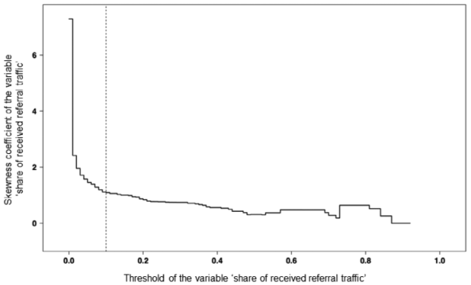

NOTE: figure/graphic rendered as an image from the PDF; its content is not machine-readable text. Caption (if any) follows as the next block.

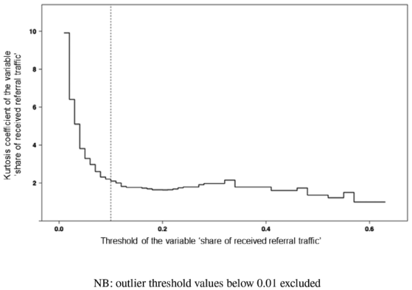

NOTE: figure/graphic rendered as an image from the PDF; its content is not machine-readable text. Caption (if any) follows as the next block.

is based on maximizing the modularity measure over all possible partitions. The higher the modularity of nodes within a subgraph is, the denser connections between the nodes within it are. Conversely, this implies that connections between nodes in different subgraphs are sparser. Alternative community detection algorithms tested generated very similar communities.

FIGURE A1 Relation between the threshold of the share of received traffic chosen and the skewness coefficient.

FIGURE A2 Relation between the threshold of the share of received traffic chosen and the kurtosis coefficient.

1870 CARBALLA-SMICHOWSKI ET AL.

Page 32

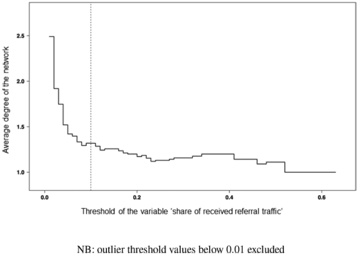

NOTE: figure/graphic rendered as an image from the PDF; its content is not machine-readable text. Caption (if any) follows as the next block.

Detection of matching problems and coordination and cooperation patterns

In this subsection, we explain how we empirically detect signs of matching problems and obtain information on the nature of the inter-platform coordination and cooperation strategies employed to solve them. To do so, we proceed in the following way. We begin by classifying platforms in terms of the main (sub)topic they cover and the (sub)service they provide, as well as regarding their competitive relations. This results in four patterns of demand-side linkages. For each pattern, we compute the difference between the intensity of demand-side linkages between the platforms (cf. Equation 1) previously identified as being within and outside a DSIPE to proxy the extent of cross-platform failures for each pattern in our sample. Then, for each pattern, we study the nature of the demand-side linkages patterns and the platforms involved. Furthermore, we analyze the cached pages containing links between the origin and the destination platform for within and outside DSIPE cases to obtain additional information on the nature of these failures and how they are solved.

Detection of demand-side linkages patterns

We create our own classification of platforms in terms of the main (sub)topic they cover and the (sub)service they provide. Each unique combination of a service and a subtopic constitutes a market. For example, the fashion online retailer platform Boozt is classified under topic “Retail,” subtopic “Fashion,” service “Marketplace” and subservice “Vendors,” the latter being distinct from subservice “Classifieds,” which describes secondhand online marketplaces. Hence,

FIGURE A3 Relation between the threshold of the share of received traffic chosen and the average degree of the network.

CARBALLA-SMICHOWSKI ET AL. 1871

Page 33

Boozt's market is “Fashion marketplace.” The classification was made on the basis of a qualitative assessment of the platforms and their own description on their websites and app stores. When more than one (sub)service or (sub)topic existed, the main one was chosen based on the number of listings when pertinent (e.g., if there were more items listed as secondhand than as new in an online marketplace, the former was chosen as the main subservice) or by detecting the most prominent one. Drawing on this classification, we establish four competitive categories conveying the extent of the overlap between the markets in which the platforms are active, as described in Table A2. This translates the competitive relation between the platforms: The more overlapping their markets are, the stronger their competition is, and vice versa.

Based on this classification, we also categorize platforms in four mutually-exclusive types: “transaction platform,” “meta-search platform,” “user-community platform,” and “other.” Table A3 explains how each type is defined.

Detection of matching problems and alignment patterns

In order to detect matching problems and alignment patterns, we create a database comprising the 113 cases of platforms exhibiting demand-side linkages of an intensity larger or equal to 1%. In our sample, platform linkages of an intensity between 1% and 10%, although not statistically significant to indicate nongeneric complementarities in demand between platforms, are sufficiently strong not to be considered noise in the sample. Platform linkages above the 10%

TABLE A2 Categories of platform markets overlap.

[output not shown]

NOTE: table converted from PDF layout to HTML text; cell boundaries are reconstructed. See PDF if exact alignment matters.

Source: Own elaboration.

TABLE A3 Types of platforms.

| Platform |  |  |
| --- | --- | --- |
| type | Description | Example |
| Transaction | Theplatformmatchesdifferenttypeofusersto | Marketplaces fooddelivery lodging , , |
|  | performatransaction | platforms |
| Meta- | Theplatformaggregatessearchresultsfrommultiple | Onlinepricecomparisontools , |
| search | sources includingotherplatforms'listings , | lodging flightsmetasearchengines , |
| User- | Theplatformhasaforum achatand/orasocial , | Specializedforums livestreaming , |
| community | networkasoneofitsmainfunctionalities | platforms |
| Other | Noneoftheabovedescriptionsapply | Portals browsers onlinemaps , , |

NOTE: table converted from PDF layout to HTML text; cell boundaries are reconstructed. See PDF if exact alignment matters.

Source: Own elaboration.

1872 CARBALLA-SMICHOWSKI ET AL.

Page 34

threshold (28 cases), in turn, indicate the existence of nongeneric complementarities in demand between platforms belonging to one of the DSIPEs depicted in Figure 1.<sup>23</sup>

Based on the above-described categorizations of platforms and their competitive relations, we establish four patterns of cross-platform linkages. Table A4 describes them. The entirety of the 113 cases match one of these patterns. For every pattern identified, we observe some platforms that managed to establish nongeneric complementarities in consumption (i.e., above the 10% threshold), and more numerous cases of platforms not having managed to create nongeneric complementarities in consumption (i.e., those below the 10% threshold). This divergence indicates the existence of a cross-platform failure that has been solved by the platforms within a DSIPE and not by those outside a DSIPE.

To obtain information on the nature of these failures and how they are solved, we rely on three types of sources. The first one is the characteristics of the platforms and their competitive relations codified in each demand-side linkage pattern. The second one is the examination of the functioning of the platforms identified (e.g., to check if a platform provides the possibility to finish a purchase in another platform) and publicly available information about their coordination and cooperation actions. Examples of the latter include press releases about partnerships or the technical descriptions of their cross-platform connectivity tools. The third one is the examination of the cached pages providing samples of referral links to the destination platform contained in the origin platform.

Building on this empirical base and current (intra-) platform ecosystems theory, in the next section, we provide insights into why and how DSIPEs emerge. In particular, we describe four strategies platforms use to solve cross-platform failures by aligning within a DSIPE.

TABLE A4 Patterns of cross-platform linkages identified.

| Features | Pattern1 | Pattern2 | Pattern3 | Pattern4 |
| --- | --- | --- | --- | --- |
| Platformfromtype | Transaction | User- | Meta-search | Other |
|  |  | community |  | combinations |
| Platformtotype | Transaction | Any | Transaction |  |
| Competitiverelations | Fullorpartial | Any | Adjacent or partially- | Adjacentor |
|  | marketoverlap |  | overlappingmarkets | unrelated |
|  |  |  |  | markets |
| CaseswithinaDSIPE | 10 | 3 | 11 | 4 |
| Mean demand -side linkages | 30% | 18% | 29% | 25% |
| intensitywithinaDSIPE |  |  |  |  |
| CasesoutsideaDSIPE | 29 | 13 | 17 | 26 |
| Mean demand -side linkages | 3% | 3% | 4% | 3% |
| intensityoutsideaDSIPE |  |  |  |  |

NOTE: table converted from PDF layout to HTML text; cell boundaries are reconstructed. See PDF if exact alignment matters.

Source: Own elaboration.

23See Appendix A “Determination of a threshold value to differentiate occasional from significant cross-platform traffic” for more details on how these thresholds were established.

CARBALLA-SMICHOWSKI ET AL. 1873

Page 35

Limitation of the original dataset

The major limitation of the original dataset is that it only captures desktop browser traffic. As a consequence, platforms such as food delivery platforms in which mobile app use is more relevant are underrepresented. However, mobile apps rarely link to each other or to external websites. Consequently, demand-side linkages would be more difficult to find using mobile app data. Moreover, the data do not allow us to distinguish business users from final users traffic. Hence, we cannot take the two-sideness of platforms (intra-platform demand-side linkages) into account in our analysis.

APPENDIX B

This appendix provides the lists of the original 166 (Table B1) and the final 241 platforms (Table B2) taken into account to carry out the empirical analysis.

TABLE B1 List of the original 166 platforms identified.

| Platform |  |  |  |
| --- | --- | --- | --- |
| admitad | daft | instagram | ryanair |
| adverts | damejidlo | invia | sapo |
| airbnb | dba | JeuxVidéo | sbazar |
| aliexpress | deliveroo | jofogas | seloger |
| allegro | dh | just-eat | seznam |
| alvolante | dinnerbooking | lafourchette | shein |
| alza | directbooking | landwirt | shop-apotheke |
| amazon | docfinder | laredoute | shopalike |
| argos | doctissimo | leboncoin | shutterstock |
| arukereso | donedeal | lieferando | skroutz |
| asos | drive | lieferservice | skyscanner |
| auto | duckduckgo | linkedin | snapchat |
| autobazar | e-shop | marktplaats | spitogatos |
| autoscout24 | ebay | medicitalia | sreality |
| autotrader | eltenedor | milanuncios | standvirtual |
| autotriti | emag | mjam | startpage |
| autovit | etuovi | mojekrpice | startpagina |
| bazar | facebook | momondo | subito |
| bazos | fdm | moto | taboola |
| bergfex | finn | myhome | takeaway |
| bestprice | flickr | netdoktor | tori |
| bilbasen | foodpanda | netpincer | totalcar |
| bing | funda | nettiauto | tradera |

NOTE: table converted from PDF layout to HTML text; cell boundaries are reconstructed. See PDF if exact alignment matters.

1874 CARBALLA-SMICHOWSKI ET AL.

Page 36

TABLE B1 (Continued)

| Platform |  |  |  |
| --- | --- | --- | --- |
| blablacar | gebrauchtwagen | njuskalo | tripadvisor |
| blocket | geizhals | nocowanie | trivago |
| bol | glami | norwegian | trovaprezzi |
| boligsiden | glovoapp | ok | twitch |
| bonprix | gohome | olx | twitter |
| boohoo | google | otodom | ubereats |
| booking | hemnet | otomoto | verkkokauppa |
| boozt | heureka | otto | vinted |
| car | holidaycheck | outbrain | wk . |
| cargurus | hotels | Pinterest | verismo |
| cars | heal | pochivka | vuokraovi |
| carsireland | idealista | pricerunner | willhaben |
| carzone | idealo | prisjakt | wizzair |
| casa | imedia | publi24 | yahoo |
| cdiscount | immobiliare | pyszne | yandex |
| ceneo | immobilienscout24 | qwant | youtube |
| coches | immoweb | ready | zalando |
| compari | immowelt | reddit |  |
| custojusto | imot | rightmove |  |

NOTE: table converted from PDF layout to HTML text; cell boundaries are reconstructed. See PDF if exact alignment matters.

TABLE B2 List of the 241 platforms analyzed.

| Platform |  |  |  |
| --- | --- | --- | --- |
| admitad | carzone | google keep _ | otto |
| adverts | casa | google mail _ | outbrain |
| airbnb | cdiscount | google maps _ | Pinterest |
| airbnb careers _ | ceneo | google news _ | pricerunner |
| airbnb design _ | coches | google patents _ | prisjakt |
| airbnb engineering _ | compari | google pay _ | publi24 |
| airbnb news _ | custojusto | google photos _ | pyszne |
| aliexpress | daft | google play _ | qwant |
| allegro | damejidlo | google podcasts _ | reddit |
| allegro tech _ | dba | google santa _ | rightmove |
| alvolante | deliveroo | google scholar _ | ryanair |
| alza | deliveroo design _ | google shopping _ | sapo |
| amazon | deliveroo engineering _ | google sites _ | sbazar |
| amazon ads _ | dh | google stadia _ | seloger |
| amazon affiliate _ | dinnerbooking | google store _ | seznam |

NOTE: table converted from PDF layout to HTML text; cell boundaries are reconstructed. See PDF if exact alignment matters.

CARBALLA-SMICHOWSKI ET AL. 1875

Page 37

TABLE B2 (Continued)

| Platform |  |  |  |
| --- | --- | --- | --- |
| amazon alexa _ | directbooking | google translate _ | shein |
| amazon care _ | docfinder | google trends _ | shopalike |
| amazon career choice _ _ | doctissimo | hemnet | shop-apotheke |
| amazon design _ | donedeal | heureka | shop-apotheke jobs _ |
| amazon developer _ | duckduckgo | holidaycheck | shutterstock |
| amazon games _ | ebay | hotels | skroutz |
| amazon jobs _ | eltenedor | idealista | skyscanner |
| amazon kindle _ | emag | idealo | snapchat |
| amazon music _ | e-shop | idealo flights _ | spitogatos |
| amazon prime _ | etuovi | idealo hotels _ | sreality |
| amazon science _ | facebook | imedia | standvirtual |
| argos | facebook design _ | immobiliare | startpage |
| argos card _ | facebook developers _ | immobilienscout24 | startpagina |
| argos careers _ | fdm | immoweb | subito |
| arukereso | fdm careers _ | immowelt | taboola |
| asos | fdm shop _ | instagram | takeaway |
| asos careers _ | fdm travel _ | invia | tori |
| auto | finn | JeuxVidéo | totalcar |
| autobazar | flickr | jofogas | tradera |
| autoscout24 | foodpanda | just-eat | tripadvisor |
| autotrader | funda | just-eat careers _ | trivago |
| autotriti | gebrauchtwagen | lafourchette | trovaprezzi |
| autovit | geizhals | landwirt | twitch |
| aws | glami | laredoute | twitter |
| aws mail _ | glovoapp | leboncoin | ubereats |
| aws training _ | gohome | lieferando | verkkokauppa |
| bazar | google | linkedin | vinted |
| bazos | google account _ | marktplaats | wk . |
| bergfex | google ads _ | medicitalia | verismo |
| bestprice | google apis _ | milanuncios | vuokraovi |
| bilbasen | google apps _ | mjam | whatsapp |
| bing | google arts _ | mojekrpice | willhaben |
| blablacar | google assistant _ | momondo | wizzair |
| blocket | google books _ | moto | yahoo |
| blocket career _ | google business _ | motopl | yahoo finance _ |
| bol | google calendar _ | myhome | yahoo mail _ |
| boligsiden | google chrome _ | netdoktor | yahoo news _ |
| bonprix | google classroom _ | netpincer | yandex |

NOTE: table converted from PDF layout to HTML text; cell boundaries are reconstructed. See PDF if exact alignment matters.

1876 CARBALLA-SMICHOWSKI ET AL.

Page 38

TABLE B2 (Continued)

| Platform |  |  |  |
| --- | --- | --- | --- |
| boohoo | google cloud _ | nettiauto | yandex afisha _ |
| booking | google datastudio _ | njuskalo | yandex mail _ |
| boozt | google dev _ | nocowanie | yandex market _ |
| car | google docs _ | norwegian | youtube |
| car info _ | google drive _ | ok | zalando |
| cargurus | google earth _ | olx |  |
| cars | google firebase _ | otodom |  |
| carsireland | google hangout _ | otomoto |  |

NOTE: table converted from PDF layout to HTML text; cell boundaries are reconstructed. See PDF if exact alignment matters.

CARBALLA-SMICHOWSKI ET AL. 1877